# Fundamental Techniques in Data Science with `R` - Practical 4

# Introduction

We will use the following packages in this practical:

```r
library(dplyr)
library(magrittr)
library(ggplot2)
library(gridExtra)
```

In this practical, you will learn how to perform regression analyses in `R` using `lm()` and inspect variables by plotting these variables, using `ggplot()`, repeating some topics of the last 3 weeks.

# Loading the dataset

In the this practical, we will use the built-in data set `iris`. This data set contains the measurement of different iris species (flowers), you can find more information [here](https://www.rdocumentation.org/packages/datasets/versions/3.6.2/topics/iris).

1. **Load the dataset and explain what variables are measured in the first three columns of your data set.**

```r
data <- iris # load the data
head(iris)   # inspect the data
```

|  | Sepal.Length | Sepal.Width | Petal.Length | Petal.Width | Species |
| --- | --- | --- | --- | --- | --- |
| 1 | 5.1 | 3.5 | 1.4 | 0.2 | setosa |
| 2 | 4.9 | 3.0 | 1.4 | 0.2 | setosa |
| 3 | 4.7 | 3.2 | 1.3 | 0.2 | setosa |
| 4 | 4.6 | 3.1 | 1.5 | 0.2 | setosa |
| 5 | 5.0 | 3.6 | 1.4 | 0.2 | setosa |
| 6 | 5.4 | 3.9 | 1.7 | 0.4 | setosa |

```r
# The data set contains three different kinds of flowers. The petal leaves and sepal leaves are measured in length and width. All measurements are in centimeters.
```

# Inspecting the dataset

A good way of eyeballing on a relation between two continuous variables is by creating a scatterplot.

2. **Plot the sepal length and the petal width variables in a `ggplot` scatter plot (`geom_points`)**

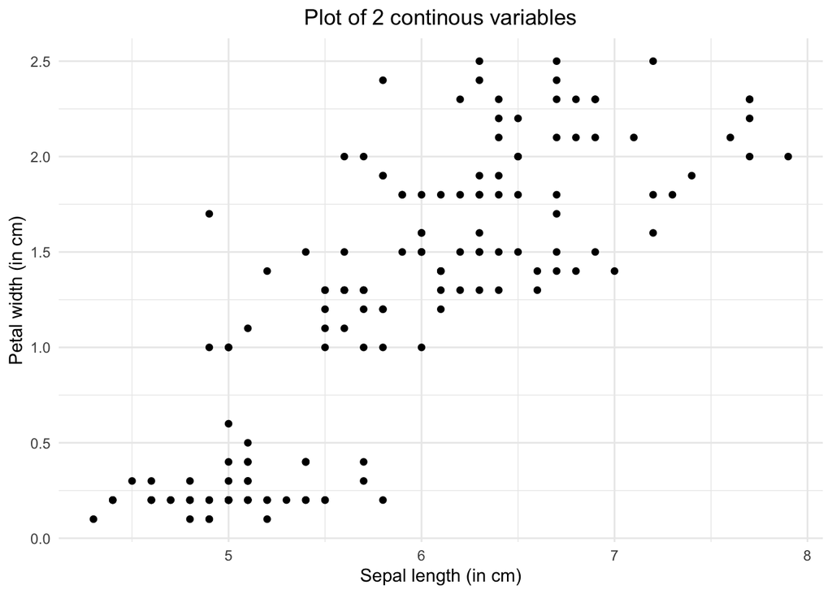

```r
ggplot(data) +
  geom_point(aes(Sepal.Length, Petal.Width)) +
  xlab("Sepal length (in cm)") +
  ylab("Petal width (in cm)") +
  labs(col = "Species") +
  theme_minimal() +
  ggtitle("Plot of 2 continous variables")  +
  theme(plot.title = element_text(hjust = 0.5))
```

A loess curve can be added to the plot to get a general idea of the relation between the two variables. You can add a loess curve to a ggplot with `stat_smooth(method = "loess")`.

3. **Add a loess curve to the plot under question 2, for further inspection.**

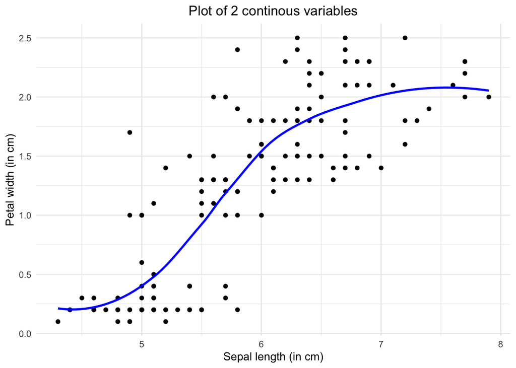

```r
ggplot(data, aes(x = Sepal.Length, y = Petal.Width)) +
  geom_point() +
  stat_smooth(method = "loess", se=F, col = "blue") +
  xlab("Sepal length (in cm)") +
  ylab("Petal width (in cm)") +
  labs(col = "Species") +
  theme_minimal() +
  ggtitle("Plot of 2 continous variables")  +
  theme(plot.title = element_text(hjust = 0.5))
```

```r
# The curve is added to the previous plot by the line `stat_smooth(method = "loess, se = F, col = "blue")`.
```

To get a clearer idea of the general trend in the data (or of the relation), a regression line can be added to the plot. A regression line can be added in the same way as a loess curve, the method argument in the function needs to be altered to `lm` to do so.

4. **Change the loess curve of the previous plot to a regression line. Describe the relation that the line indicates.**

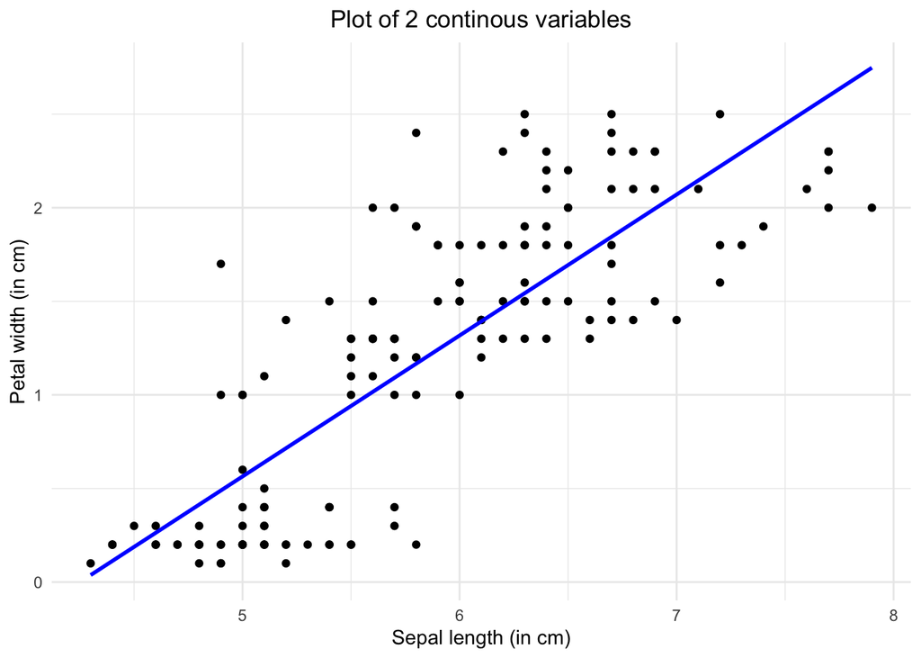

```r
# In comparison to the previous plot, we now adjust "method = "loess"" to "method = "lm"".
ggplot(data, aes(x = Sepal.Length, y = Petal.Width)) +
  geom_point() +
  stat_smooth(method = "lm", se=F, col = "blue") +
  xlab("Sepal length (in cm)") +
  ylab("Petal width (in cm)") +
  labs(col = "Species") +
  theme_minimal() +
  ggtitle("Plot of 2 continous variables")  +
  theme(plot.title = element_text(hjust = 0.5))
```

```r
# The line indicates that there seems to be a more or less linear positive relation between the two plotted variables. This means that an increase in sepal length probably indicates an increase in petal width as well.
```

# Simple linear regression

With the `lm()` function, you can specify a linear regression model. You can save a model in an object and request summary statistics with the `summary()` command. The model is always specified with the code `outcome_variable ~ predictor`.

When a model is stored in an object, you can ask for the coefficients with `coefficients()`. The next code block shows how you would specify a model where petal width is predicted by sepal width, and how summary statistics for this model would look like

```r
# Specify model: outcome = petal width, predictor = sepal width
iris_model1 <- lm(Petal.Width ~ Sepal.Width,
                  data = iris)

summary(iris_model1)
```

```
##
## Call:
## lm(formula = Petal.Width ~ Sepal.Width, data = iris)
##
## Residuals:
##      Min       1Q   Median       3Q      Max
## -1.38424 -0.60889 -0.03208  0.52691  1.64812
##
## Coefficients:
##             Estimate Std. Error t value Pr(>|t|)
## (Intercept)   3.1569     0.4131   7.642 2.47e-12 ***
## Sepal.Width  -0.6403     0.1338  -4.786 4.07e-06 ***
## ---
## Signif. codes:  0 '***' 0.001 '**' 0.01 '*' 0.05 '.' 0.1 ' ' 1
##
## Residual standard error: 0.7117 on 148 degrees of freedom
## Multiple R-squared:  0.134,  Adjusted R-squared:  0.1282
## F-statistic: 22.91 on 1 and 148 DF,  p-value: 4.073e-06
```

The summary of the model provides:

- The model formula;
- Estimated coefficients (with standard errors and their significance tests);
- Information on the residuals;
- A general test for the significance of the model (F-test);
- The (adjusted) R squared as a metric for model performance.

Individual elements can be extracted by calling specific model elements (e.g. `iris_model1$coefficients`).

5. **Specify a regression model where Sepal length is predicted by Petal width. Store this model as `model1. Supply summary statistics for this model.**

```r
# specify model
model1 <- lm(Sepal.Length ~ Petal.Width,
             data = data)

# ask for summary
summary(model1)
```

```
##
## Call:
## lm(formula = Sepal.Length ~ Petal.Width, data = data)
##
## Residuals:
##      Min       1Q   Median       3Q      Max
## -1.38822 -0.29358 -0.04393  0.26429  1.34521
##
## Coefficients:
##             Estimate Std. Error t value Pr(>|t|)
## (Intercept)  4.77763    0.07293   65.51   <2e-16 ***
## Petal.Width  0.88858    0.05137   17.30   <2e-16 ***
## ---
## Signif. codes:  0 '***' 0.001 '**' 0.01 '*' 0.05 '.' 0.1 ' ' 1
##
## Residual standard error: 0.478 on 148 degrees of freedom
## Multiple R-squared:  0.669,  Adjusted R-squared:  0.6668
## F-statistic: 299.2 on 1 and 148 DF,  p-value: < 2.2e-16
```

6. **Based on the summary of the model, give a substantive interpretation of the regression coefficient.**

```r
# The regression coefficient indicates the amount of change in the predicted variable when the predictor variable is changed with one unit. In case of the example model, this means that for every centimeter increase in the width of a petal leaf, the predicted length of a sepal leaf increases by 0.89 cm.
```

7. **Relate the summary statistics and coefficients to the plots you made in questions 2 - 4.**

```r
# The coefficients seem to be in accordance with the earlier plots. They are not exactly the same, but indicate a similar positive relationship.
```

# Multiple linear regression

You can add additional predictors to a model. This can improve the fit and the predictions. When multiple predictors are used in a regression model, it’s called a Multiple linear regression. You specify this model as `outcome_variable ~ predictor_1 + predictor_2 + ... + predictor_n`.

8. **Add Petal length as a second predictor to the model specified as `model1` and store this under the name `model2`, and supply summary statistics. Again, give a substantive interpretation of the coefficients and the model.**

```r
# Specify additional predictors
model2 <- lm(Sepal.Length ~ Petal.Width + Petal.Length,
             data = data)

# Ask for summary statistics again
summary(model2)
```

```
##
## Call:
## lm(formula = Sepal.Length ~ Petal.Width + Petal.Length, data = data)
##
## Residuals:
##      Min       1Q   Median       3Q      Max
## -1.18534 -0.29838 -0.02763  0.28925  1.02320
##
## Coefficients:
##              Estimate Std. Error t value Pr(>|t|)
## (Intercept)   4.19058    0.09705  43.181  < 2e-16 ***
## Petal.Width  -0.31955    0.16045  -1.992   0.0483 *
## Petal.Length  0.54178    0.06928   7.820 9.41e-13 ***
## ---
## Signif. codes:  0 '***' 0.001 '**' 0.01 '*' 0.05 '.' 0.1 ' ' 1
##
## Residual standard error: 0.4031 on 147 degrees of freedom
## Multiple R-squared:  0.7663, Adjusted R-squared:  0.7631
## F-statistic:   241 on 2 and 147 DF,  p-value: < 2.2e-16
```

```r
# When comparing the coefficients of model 2 with the coefficients of model 1, we can see that adding a predictor can change the coefficients of other predictors as well (it is a new model after all). In this example, it is notable that the coefficient for petal width has become a negative number, while it was positive in model 1.
```

# Categorical predictors

Up to here, we only included continuous predictors in our models. We will now include a categorical predictor in the model as well.

When a categorical predictor is added, this predictor is split in several contrasts (or dummies), where each group is compared to a reference group. In our example Iris data, the variable ‘Species’ is a categorical variable that indicate the species of flower. This variable can be added as example for a categorical predictor. Contrasts, and thus the dummy coding, can be inspected through `contrasts()`.

```r
# Create 3rd model with categorical predictor
model3 <- lm(Sepal.Length ~ Sepal.Width + Petal.Length + Species,
             data = data)

# Ask for summary data
summary(model3)
```

```
##
## Call:
## lm(formula = Sepal.Length ~ Sepal.Width + Petal.Length + Species,
##     data = data)
##
## Residuals:
##      Min       1Q   Median       3Q      Max
## -0.82156 -0.20530  0.00638  0.22645  0.74999
##
## Coefficients:
##                   Estimate Std. Error t value Pr(>|t|)
## (Intercept)        2.39039    0.26227   9.114 5.94e-16 ***
## Sepal.Width        0.43222    0.08139   5.310 4.03e-07 ***
## Petal.Length       0.77563    0.06425  12.073  < 2e-16 ***
## Speciesversicolor -0.95581    0.21520  -4.442 1.76e-05 ***
## Speciesvirginica  -1.39410    0.28566  -4.880 2.76e-06 ***
## ---
## Signif. codes:  0 '***' 0.001 '**' 0.01 '*' 0.05 '.' 0.1 ' ' 1
##
## Residual standard error: 0.3103 on 145 degrees of freedom
## Multiple R-squared:  0.8633, Adjusted R-squared:  0.8595
## F-statistic: 228.9 on 4 and 145 DF,  p-value: < 2.2e-16
```

```r
# In the output, we see that 'Species' has multiple rows of output, and that one species (Setosa) does not seem to show. Setosa is the reference group. The other two lines are those respecitve groups compared to the setosa group. This means that that the predicted sepal length of a versicolor would be .9558 lower than the predicted value of a setosas with the same values on the other variables.
```

# Model comparison

Now you have created multiple models, you can compare how well these models function (compare the model fit). There are multiple ways of testing the model fit and to compare models, as explained in the lecture and the reading material. In this practical, we use the following:

- AIC (use the function `AIC()` on the model object)
- BIC (use the function `BIC()` on the model object)
- MSE (use `MSE()` of the `MLmetrics` package, or calculate by transforming the `model$residuals`)
- Deviance test (use `anova()` to compare 2 models)
10. **Compare the fit of the model specified under question 5 and the model specified under question 8. Use all four fit comparison methods listed above. Interpret the fit statistics you obtain/tests you use to compare the fit.**

```r
AICvalues <- rbind(AIC(model1), AIC(model2))
BICvalues <- rbind(BIC(model1), BIC(model2))
MSEvalues <- rbind(mean(model1$residuals^2),
                    mean(model2$residuals^2))

modelfitvalues <- cbind(AICvalues, BICvalues, MSEvalues)
rownames(modelfitvalues) <- c("model1", "model2")
colnames(modelfitvalues) <- c("AIC", "BIC", "MSE")
modelfitvalues
```

```
##             AIC      BIC       MSE
## model1 208.2215 217.2534 0.2254326
## model2 158.0468 170.0894 0.1592046
```

```r
# We see that the second AIC is lower, and thus this model has a better fit-complexity trade-off. The BIC has the same conclusion as the AIC in this case. The MSE of the second model is lower, and therefore indicates less error and a better fit.

# R2 difference test (deviance)
anova(model1, model2)
```

|  | Res.Df | RSS | Df | Sum of Sq | F | Pr(>F) |
| --- | --- | --- | --- | --- | --- | --- |
| 1 | 148 | 33.81489 | NA | NA | NA | NA |
| 2 | 147 | 23.88069 | 1 | 9.934196 | 61.15094 | 9.414477e-13 |

```r
# The residual sum of squares is significantly lower for model 2, indicating a better fit for this model
```